# Evolution and adaptation

BIOL 350, California State University-Long Beach, Fall 2019

Environments play a major role in evolution. They affect the survival and reproduction of organisms, ultimately shaping phenotypes within populations. The effect of environments can be fast or slow, constant or acute but the many limitations we have in data collection (time, logistics, funding) often impede us to quantify such effects on evolution. On the other hand, there are climatic events that are so extreme that their effects on populations are immediate, opening opportunities to the quantification of selection. Donihue and colleagues (2018) measured morphology and performance in anole lizards “before” and “after” hurricanes Irma and Maria. Their main goal was to asses hurricane-induced selection.

The main objectives for today are to:

- Quantify morphological changes associated to adaptation in anoles following an extreme climatic event
- Carry out and interpret simple linear regression analysis in R

Resources:

- [Donihue CM, Herrel A, Fabre A, Kamath A, Geneva AJ, Schoener TW, Kolbe JJ, Losos JB (2018) Hurricane-induced selection on the morphology of an island lizard. Nature 560(7716): 88-91](https://datadryad.org/resource/doi:10.5061/dryad.2t41r64)
- [Felipe Rego](https://feliperego.github.io/blog/2015/10/23/Interpreting-Model-Output-In-R)

Datasets:

- [Donihue 2018-01-00672 Hurricanes Data](https://datadryad.org/resource/doi:10.5061/dryad.2t41r64)

**Part I: Morphological changes following extreme events**

Step 1: Generate a hypothesis on potential changes in the average value of a morphological trait

Go ahead, download Donihue et al. (2018) data to your working directory and import it to RStudio from [Dryad](https://datadryad.org/resource/doi:10.5061/dryad.2t41r64).

```r
# Changing the dataframe's name
 anol <- Donihue_2018_01_00672_Hurricanes_Data

# Checking availability of data before and after the hurricane
anol$Hurricane
```

Step 2. Plot the data for your hypothesis

```r
# Example for femur and svl.
#Subsetting (filtering) the data from before and after the hurricane
before <- subset(anol,Hurricane=="Before")
before

after <- subset(anol,Hurricane=="After")
after

#Plotting femur vs svl before the hurricane
plot(before$SVL,before$Femur,col="blue",ylim = c(5,16),xlim=c(40,65))
```

[output not shown]

```r
#Plotting femur vs svl after the hurricane
plot(after$SVL,after$Femur,col="red",ylim = c(5,16),xlim=c(40,65))
```

[output not shown]

**Part II: Modeling the data with regressions**

In Class 03 you learned about correlation analysis which estimates the correlation coefficient r. A more advanced but related statistics is the simple linear regression analysis. Simple linear regression is useful for finding linear relationships between two continuous variables. The main objective is to obtain a line that best fits the data. Check the figure below. The best fit line is the one for which total prediction error (data points in red) are as small as possible. Here, error is defined as the distance (green) between the point to the regression line (blue).

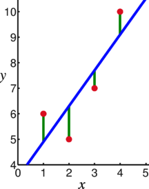

**Figure 1.** In linear regression, the observations (red) are assumed to be the result of random deviations (green) from an underlying relationship (blue) between a dependent variable (y) and an independent variable (x) (https://commons.wikimedia.org/w/index.php?curid=4099808)

Therefore, linear regression - in contrast to correlation - gives a slope defining the change in the dependent variable by changing the independent variable by unit distance. The intercept in a linear regression gives the value of the dependent variable if the independent variable is set to zero. Finally, linear regression can give you a prediction.

lm() is used to fit linear models in R. Just like for *t*-test, the first argument is the dependent variable, the second argument is the independent variable, both separated by “~”.

```r
# Linear regression between SVL and Femur
my_lm <- lm(anol$Femur~anol$SVL)
summary(my_lm)
```

[output not shown]

> **Challenge:** (1) Test your hypothesis with linear regression and interpret the R output.

**Interpreting (some of the) R output**

Call: The first item shown in the output is the formula R used to fit the data (the formula you just wrote).

Residuals: The next item in the model output are the residuals. Residuals are essentially the difference between the actual observed values from the dependent variable (femur length) and the values that the model predicted (the line). The Residuals section breaks it down into 5 summary points or descriptive statistics (minimum, first quantile, median, third quantile, maximum). These stats give you an idea of how symmetric (normally distributed) is your data.

**FIN**

**Great Work!**